# Over The Air Update Guide

## 8.2 GitHub CDN Getting Started

The following steps describe how to use GitHub CDN.

1. Create an account at gitHub.
2. Create new repository by pressing on “Create new…” (see Figure 24).

[figure not shown]

   **Fig. 24: Create New**
3. Choose New Repository (Figure 25).

[figure not shown]

   **Fig. 25: New Repository**
4. Name the repository, select public or private access types, and press Create repository, as shown in Figure 26.

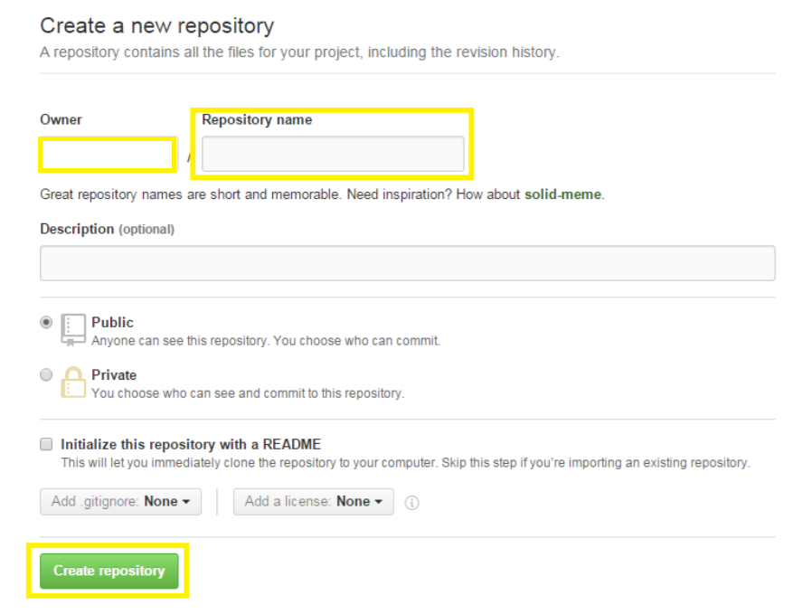

   **Fig. 26: Create New Repository**
5. Save the repository URL, as shown in Figure 27. An example would be: `https://github.com/<username>/<repository_name>`

[figure not shown]

   **Fig. 27: Save Repository**

   Following instructions shows how to activate a GitHub repository using Git GUI on the user’s PC. Download the Git GUI from here: https://git-for-windows.github.io/.
6. Create a directory on your PC.
7. Right-click to open Git options, and choose Git Bash Here, as shown in Figure 28:

[figure not shown]

   ```
   git init
   git clone https://github.com/<username>/<repository>
   git add cd <user directory>
   git add <user tar file>
   git commit -a -m 'add OTA …’
   git remote
   git push origin master
   ```

9. Enter the username and password. Now the SP TAR file can be seen in github.
10. After the GitHub CDN repository is activated, open a cloud OTA example application and edit the `otauser.h` file, as shown in: Figure 29. Uncomment `OTA_SERVER_GITHUB`:

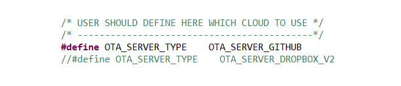

    **Fig. 29: Set Server Name in otauser.h**

    Edit the fields shown in Figure 30.

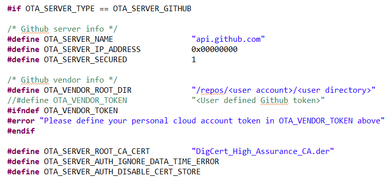

    **Fig. 30: Set Directory in otauser.h**
11. Build the relevant cloud OTA application, and run.

# 9 Local Link Support

OTA on a local link is done from a local mobile device, not from the cloud. Part of the OTA library can be used to support OTA on a local link network. The application gets the archive file chunks using a NetApp API from a local mobile device, and uses only the OtaArchive and OtaJson modules to handle the archive files chunks, processes them, and stores them on the requested files in the NWP file system.

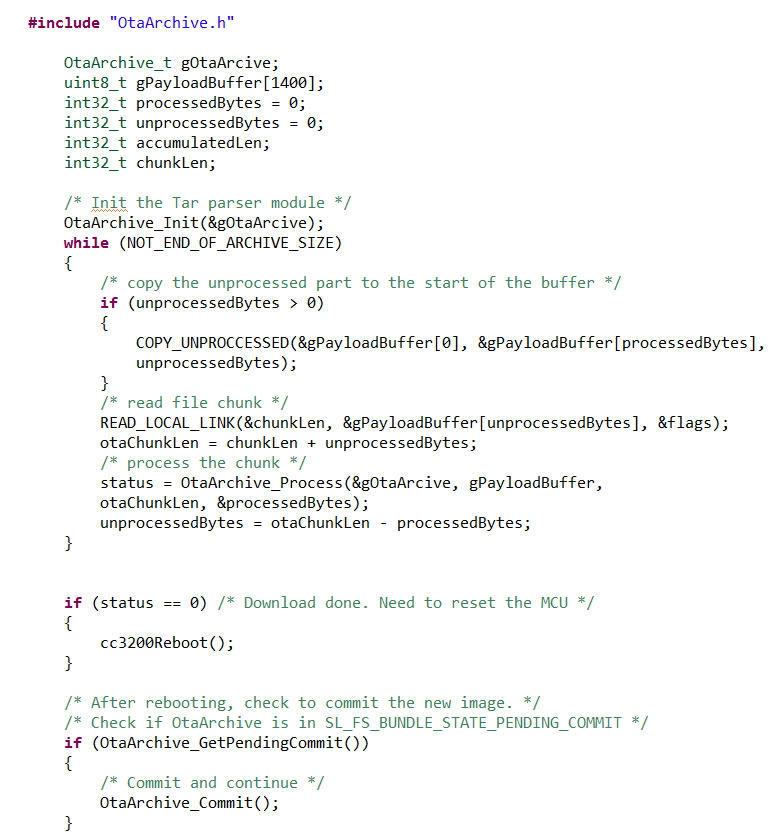

# 10 Support New CDN Vendor

The OTA lib supports two CDN vendors: Dropbox and Github. A vendor can use another CDN server. This chapter describes how to define this custom CDN.

# 10.1 otauser.h

Add the CDN to the list and define it as the selected server:

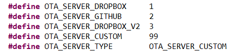

Add custom vendors defines section:

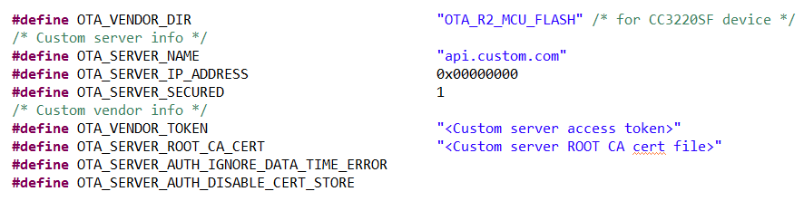

The host application can skip the `GetHostByName()` and define the server IP address in `OTA_SERVER_IP_ADDRESS`. If the custom server does not support server authentication and domain name verification, `OTA_SERVER_ROOT_CA_CERT` should be undefined.

# 10.2 ota/source/CdnVendors/Custom.c

# 10.3 ota/source/CdnVendors/CdnVendors.h

Add custom vendor macros:

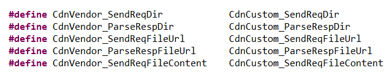